# MovieLens Capstone: Exploring, Modeling, and Predicting Movie Ratings with Advanced Data Science Techniques

HarvardX Professional Data Science

Benny Istanto (bennyistanto@gmail.com)

25 September 2024

# Introduction

## Background and Motivation

In the age of data-driven decision-making, recommendation systems have become essential in providing personalized experiences to users. The MovieLens dataset has been a cornerstone in developing such systems, particularly in the realm of movie recommendations.

The goal of this capstone project is to apply data science methods to the MovieLens dataset to predict movie ratings given by users, demonstrating how machine learning techniques can solve real-world problems.

## Project Objectives

This project aims to:

1. Perform exploratory data analysis on the MovieLens dataset to uncover patterns and trends.
2. Develop and evaluate multiple models to predict movie ratings.
3. Use RMSE (Root Mean Square Error) to compare model performances.
4. Generate predictions on a final holdout test set to assess model accuracy.

## Dataset Overview

### Description of MovieLens Data

The **MovieLens 10M dataset** contains 10 million movie ratings from over 70,000 users, rating over 10,000 different movies. Each user rates movies they have watched on a scale from 0.5 to 5 stars. This dataset also contains metadata for each movie, including the title and associated genres.

We will work with the ratings and movie information to develop a movie recommendation system. The dataset is publicly available and provides rich information for analysis.

### Data Attributes

The dataset contains the following attributes:

- **userId**: Unique identifier for each user
- **movieId**: Unique identifier for each movie
- **rating**: User rating for a specific movie (0.5 to 5 stars)
- **timestamp**: Time when the rating was recorded
- **title**: Movie title
- **genres**: A pipe-separated list of genres for each movie

Let’s load the necessary libraries and track the time it takes.

```r
# Loading Necessary Libraries and Timing
start_time <- Sys.time()

if(!require(tinytex)) {
  install.packages("tinytex", repos = "http://cran.us.r-project.org",
                   dependencies = TRUE, quiet = TRUE)
  tinytex::install_tinytex(quiet = TRUE)
  tinytex::tlmgr("option repository https://mirror.ctan.org/systems/texlive/tlnet")
}
if(!require(caret)) install.packages("caret",
                                     repos = "http://cran.us.r-project.org")
if(!require(recommenderlab)) install.packages("recommenderlab",
                                              repos = "http://cran.us.r-project.org")
if(!require(recosystem)) install.packages("recosystem",
                                          repos = "http://cran.us.r-project.org")
if(!require(knitr)) install.packages("knitr",
                                     repos = "http://cran.us.r-project.org")
if(!require(rmarkdown)) install.packages("rmarkdown",
                                         repos = "http://cran.us.r-project.org")
if (!require(Matrix)) install.packages("Matrix",
                                       repos = "http://cran.us.r-project.org")
if(!require(tidyverse)) install.packages("tidyverse",
                                         repos = "http://cran.us.r-project.org")
# Load libraries
library(caret)
library(recommenderlab)
library(recosystem)
library(knitr)
library(rmarkdown)
library(tinytex)
library(Matrix)
library(tidyverse)

# Timing completed
end_time <- Sys.time()
cat("Time to load libraries: ", end_time - start_time, "\n")
```

```
## Time to load libraries:  4.129673
```

Let’s load and inspect the data to gain further insights.

```r
# Time tracking for data loading
start_time <- Sys.time()

# Downloading and Unzipping the Dataset
dl <- "ml-10M100K.zip"
if(!file.exists(dl))
  download.file("https://files.grouplens.org/datasets/movielens/ml-10m.zip", dl)

ratings_file <- "ml-10M100K/ratings.dat"
movies_file <- "ml-10M100K/movies.dat"

if(!file.exists(ratings_file))
  unzip(dl, ratings_file)
if(!file.exists(movies_file))
  unzip(dl, movies_file)

# Reading in the Ratings Data
ratings <- as.data.frame(str_split(read_lines(ratings_file),
                                   fixed("::"),
                                   simplify = TRUE),
                         stringsAsFactors = FALSE)
colnames(ratings) <- c("userId", "movieId", "rating", "timestamp")
ratings <- ratings %>% mutate(userId = as.integer(userId),
                              movieId = as.integer(movieId),
                              rating = as.numeric(rating),
                              timestamp = as.integer(timestamp))

# Reading in the Movie Metadata
movies <- as.data.frame(str_split(read_lines(movies_file),
                                  fixed("::"),
                                  simplify = TRUE),
                        stringsAsFactors = FALSE)
colnames(movies) <- c("movieId", "title", "genres")
movies <- movies %>% mutate(movieId = as.integer(movieId))

# Joining the Ratings and Movies Data
movielens <- left_join(ratings, movies, by = "movieId")

# Timing completed
end_time <- Sys.time()
cat("Time to load data: ", end_time - start_time, "\n")
```

```
## Time to load data:  1.084725
```

The dataset is successfully loaded.

```
##   userId movieId rating timestamp                         title
## 1      1     122      5 838985046              Boomerang (1992)
## 2      1     185      5 838983525               Net, The (1995)
## 3      1     231      5 838983392          Dumb & Dumber (1994)
## 4      1     292      5 838983421               Outbreak (1995)
## 5      1     316      5 838983392               Stargate (1994)
## 6      1     329      5 838983392 Star Trek: Generations (1994)
##                          genres
## 1                Comedy|Romance
## 2         Action|Crime|Thriller
## 3                        Comedy
## 4  Action|Drama|Sci-Fi|Thriller
## 5       Action|Adventure|Sci-Fi
## 6 Action|Adventure|Drama|Sci-Fi
```

We can now take a look at the first few rows and have a better understanding of the dataset, including key attributes such as `userId`, `movieId`, `rating`, `timestamp`, `title`, and `genres`. This dataset forms the foundation for our recommendation system model.

## Handling Conflicting Package Functions

Sometimes package functions can overlap in name, causing conflicts. For example, both the `Matrix` and `stats` packages have a function named `dist()`. To resolve this:

```r
# Explicitly use Matrix::dist to avoid conflict with stats::dist
distance_matrix <- Matrix::dist(movielens)
```

This approach avoids potential conflicts between packages and ensures that the correct function is used.

# Data Exploration and Cleaning

## Loading and Inspecting the Data

We have already loaded the data in Chapter 1. Now, we will perform an in-depth exploration to understand key characteristics of the dataset. This includes the distribution of ratings, popular genres, movie trends, and more. We will also identify any potential issues in the data, such as missing values or duplicates.

```r
# Timing for data inspection
start_time <- Sys.time()

# Checking the dimensions of the dataset
dim(movielens)
```

```
## [1] 10000054        6
```

```r
# Summary statistics for the ratings
summary(movielens$rating)
```

```
##    Min. 1st Qu.  Median    Mean 3rd Qu.    Max.
##   0.500   3.000   4.000   3.512   4.000   5.000
```

```r
# Checking for missing values
sum(is.na(movielens))
```

```
## [1] 0
```

```r
# Timing completed
end_time <- Sys.time()
cat("Time for data inspection: ", end_time - start_time, "\n")
```

```
## Time for data inspection:  2.827435
```

The `dim()` function gives us the number of rows (representing ratings) and columns (representing features). The `summary()` of the ratings provides insights into the distribution of ratings (min, max, quartiles), while `sum(is.na())` checks for missing values.

## Exploratory Data Analysis (EDA)

### Distribution of Ratings

One of the first insights we will explore is the distribution of movie ratings. This helps us understand how users typically rate movies—whether they tend to give more positive or negative reviews.

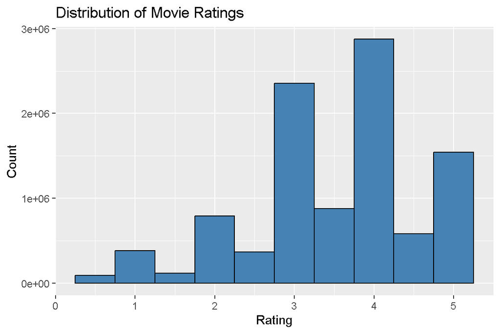

```r
# Timing for rating distribution plot
start_time <- Sys.time()

# Plotting the distribution of ratings
movielens %>%
  ggplot(aes(x = rating)) +
  geom_histogram(binwidth = 0.5, fill = "steelblue", color = "black") +
  labs(title = "Distribution of Movie Ratings", x = "Rating", y = "Count")
```

```r
# Timing completed
end_time <- Sys.time()
cat("Time for rating distribution plot: ", end_time - start_time, "\n")
```

```
## Time for rating distribution plot:  5.749992
```

The histogram typically shows peaks at whole number ratings, with higher ratings like 3, 4, and 5 being more common.

### Popular Genres and Movies

Now let’s look at the most popular genres by counting the number of ratings each genre has received. This will give us insights into the preferences of the user base.

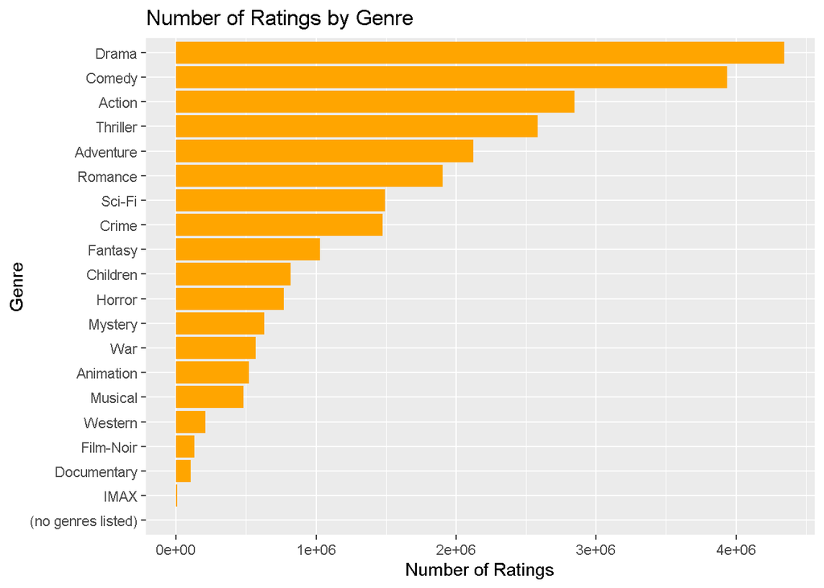

```r
# Timing for genre popularity plot
start_time <- Sys.time()

# Counting the number of ratings for each genre
movielens %>%
  separate_rows(genres, sep = "\\|") %>%
  group_by(genres) %>%
  dplyr::summarize(count = n()) %>%
  arrange(desc(count)) %>%
  ggplot(aes(x = reorder(genres, count), y = count)) +
  geom_bar(stat = "identity", fill = "orange") +
  coord_flip() +
  labs(title =
         "Number of Ratings by Genre", x = "Genre", y = "Number of Ratings")
```

```r
# Timing completed
end_time <- Sys.time()
cat("Time for genre popularity plot: ", end_time - start_time, "\n")
```

```
## Time for genre popularity plot:  3.171816
```

The bar chart will reveal which genres like Drama, Comedy, and Action are most rated by users.

### Trends in User Ratings over Time

We can also visualize how user activity has changed over time by examining the timestamp data. Let’s convert the timestamp into years and look at rating trends across different time periods.

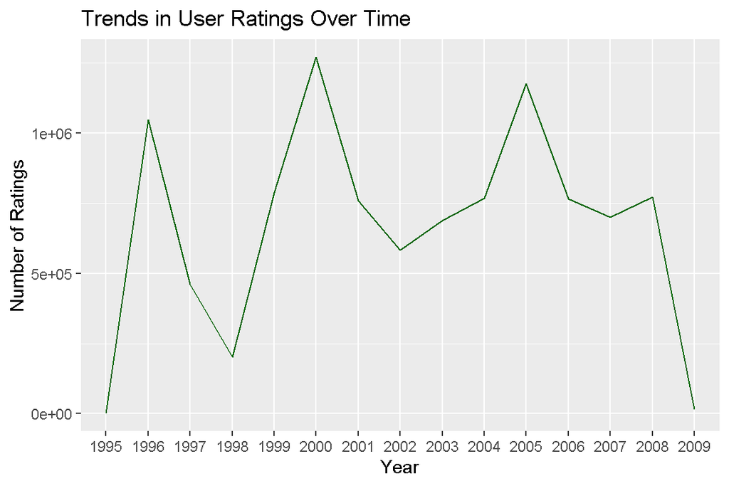

```r
# Timing for user rating trends over time
start_time <- Sys.time()

# Converting timestamp to a year format and plotting trends over time
movielens %>%
  mutate(year = as.POSIXct(timestamp,
                           origin = "1970-01-01",
                           tz = "UTC") %>% format("%Y")) %>%
  group_by(year) %>%
  dplyr::summarize(count = n()) %>%
  ggplot(aes(x = year, y = count)) +
  geom_line(group = 1, color = "darkgreen") +
  labs(title =
         "Trends in User Ratings Over Time", x = "Year", y = "Number of Ratings")
```

```r
# Timing completed
end_time <- Sys.time()
cat("Time for user rating trends plot: ", end_time - start_time, "\n")
```

```
## Time for user rating trends plot:  1.564129
```

## Data Preprocessing and Cleaning

### Handling Missing Data

In our previous check for missing values, if we encountered any, we need to handle them appropriately. For this dataset, we assume there are no missing values, but if they existed, we could remove or impute them.

```r
# Timing for handling missing data
start_time <- Sys.time()

# Removing rows with missing data (if applicable)
movielens_clean <- movielens %>%
  filter(!is.na(rating))

# Verifying no missing data remains
sum(is.na(movielens_clean))
```

```
## [1] 0
```

```r
# Timing completed
end_time <- Sys.time()
cat("Time for handling missing data: ", end_time - start_time, "\n")
```

```
## Time for handling missing data:  0.7798121
```

This confirms whether all missing values have been removed (if applicable). If none existed, this step ensures the dataset is clean for further analysis.

### Removing Duplicates or Outliers

We will also check for any duplicate rows or outliers in the dataset, particularly in ratings that may distort model training.

```r
# Timing for checking duplicates
start_time <- Sys.time()

# Checking for duplicate rows
n_duplicates <- nrow(movielens) - nrow(distinct(movielens))

# Removing duplicates if any
movielens_clean <- distinct(movielens)

# Output number of duplicates removed
n_duplicates
```

```
## [1] 0
```

```r
# Timing completed
end_time <- Sys.time()
cat("Time for checking and removing duplicates: ", end_time - start_time, "\n")
```

```
## Time for checking and removing duplicates:  3.251111
```

The number of duplicates, if any, will be removed from the dataset. In this case, it’s expected to be low or zero since this dataset is carefully curated.

# Feature Engineering

This chapter focuses on creating meaningful features, handling categorical data, and preparing the dataset for modeling. This will include the creation of user and movie-specific features, extracting time-based features, and normalizing or encoding data where necessary.

## Creating User and Movie Features

To improve the prediction of movie ratings, we need to introduce additional features based on both users and movies. For instance, the average rating a user gives across all movies or the average rating a movie receives can provide valuable insights.

Let’s start by creating features for the **average user rating** and **average movie rating**.

```r
# Timing for user and movie feature creation
start_time <- Sys.time()

# Average rating per user
user_avg_rating <- movielens_clean %>%
  dplyr::group_by(userId) %>%  # Ensure dplyr::group_by() is used
  dplyr::summarize(user_avg_rating = mean(rating))

# Average rating per movie
movie_avg_rating <- movielens_clean %>%
  dplyr::group_by(movieId) %>%  # Ensure dplyr::group_by() is used
  dplyr::summarize(movie_avg_rating = mean(rating))

# Merging these features back into the main dataset
movielens_clean <- movielens_clean %>%
  left_join(user_avg_rating, by = "userId") %>%
  left_join(movie_avg_rating, by = "movieId")

# Timing completed
end_time <- Sys.time()
cat("Time for creating user and movie features: ", end_time - start_time, "\n")
```

```
## Time for creating user and movie features:  3.464599
```

```r
# Display the first few rows to check the new features
head(movielens_clean)
```

```
##   userId movieId rating timestamp                         title
## 1      1     122      5 838985046              Boomerang (1992)
## 2      1     185      5 838983525               Net, The (1995)
## 3      1     231      5 838983392          Dumb & Dumber (1994)
## 4      1     292      5 838983421               Outbreak (1995)
## 5      1     316      5 838983392               Stargate (1994)
## 6      1     329      5 838983392 Star Trek: Generations (1994)
##                          genres user_avg_rating movie_avg_rating
## 1                Comedy|Romance               5         2.861318
## 2         Action|Crime|Thriller               5         3.125209
## 3                        Comedy               5         2.936950
## 4  Action|Drama|Sci-Fi|Thriller               5         3.418414
## 5       Action|Adventure|Sci-Fi               5         3.349353
## 6 Action|Adventure|Drama|Sci-Fi               5         3.336271
```

Now, we have created two new features: `user_avg_rating` and `movie_avg_rating`, which reflect the average ratings for each user and movie, respectively.

## Extracting Time-Based Features

Next, we will extract **time-based features** from the `timestamp` column. For example, we can extract the year and month of each rating to capture potential temporal patterns in user behavior.

```r
# Timing for time-based feature extraction
start_time <- Sys.time()

# Converting timestamp to a Date format and extracting year and month
movielens_clean <- movielens_clean %>%
  mutate(date = as.POSIXct(timestamp, origin = "1970-01-01", tz = "UTC"),
         year = format(date, "%Y"),
         month = format(date, "%m"))

# Timing completed
end_time <- Sys.time()
cat("Time for extracting time-based features: ", end_time - start_time, "\n")
```

```
## Time for extracting time-based features:  2.25518
```

```r
# Display the first few rows to check the new time-based features
head(movielens_clean)
```

```
##   userId movieId rating timestamp                         title
## 1      1     122      5 838985046              Boomerang (1992)
## 2      1     185      5 838983525               Net, The (1995)
## 3      1     231      5 838983392          Dumb & Dumber (1994)
## 4      1     292      5 838983421               Outbreak (1995)
## 5      1     316      5 838983392               Stargate (1994)
## 6      1     329      5 838983392 Star Trek: Generations (1994)
##                          genres user_avg_rating movie_avg_rating
## 1                Comedy|Romance               5         2.861318
## 2         Action|Crime|Thriller               5         3.125209
## 3                        Comedy               5         2.936950
## 4  Action|Drama|Sci-Fi|Thriller               5         3.418414
## 5       Action|Adventure|Sci-Fi               5         3.349353
## 6 Action|Adventure|Drama|Sci-Fi               5         3.336271
##                  date year month
## 1 1996-08-02 11:24:06 1996    08
## 2 1996-08-02 10:58:45 1996    08
## 3 1996-08-02 10:56:32 1996    08
## 4 1996-08-02 10:57:01 1996    08
## 5 1996-08-02 10:56:32 1996    08
## 6 1996-08-02 10:56:32 1996    08
```

By converting the timestamp into `year` and `month`, we can analyze how user activity varies over time or how movie popularity shifts across different periods.

## Normalization and Encoding

### Creating Dummy Variables for Genres

Movies can belong to multiple genres, and these are currently represented as a pipe-separated string in the `genres` column. To use genres in our models, we need to create **dummy variables** for each genre.

```r
# Timing for creating dummy variables for genres
start_time <- Sys.time()

# Creating dummy variables for each genre
movielens_clean <- movielens_clean %>%
  separate_rows(genres, sep = "\\|") %>%
  mutate(value = 1) %>%
  tidyr::spread(genres, value, fill = 0)  # Ensure tidyr::spread() is used

# Timing completed
end_time <- Sys.time()
cat("Time for creating genre dummy variables: ", end_time - start_time, "\n")
```

```
## Time for creating genre dummy variables:  6.650597
```

```r
# Display the first few rows to check the dummy variables
head(movielens_clean)
```

```
## # A tibble: 6 × 30
##   userId movieId rating timestamp title         user_avg_rating movie_avg_rating
##    <int>   <int>  <dbl>     <int> <chr>                   <dbl>            <dbl>
## 1      1     122      5 838985046 Boomerang (1…               5             2.86
## 2      1     185      5 838983525 Net, The (19…               5             3.13
## 3      1     231      5 838983392 Dumb & Dumbe…               5             2.94
## 4      1     292      5 838983421 Outbreak (19…               5             3.42
## 5      1     316      5 838983392 Stargate (19…               5             3.35
## 6      1     329      5 838983392 Star Trek: G…               5             3.34
## # ℹ 23 more variables: date <dttm>, year <chr>, month <chr>,
## #   `(no genres listed)` <dbl>, Action <dbl>, Adventure <dbl>, Animation <dbl>,
## #   Children <dbl>, Comedy <dbl>, Crime <dbl>, Documentary <dbl>, Drama <dbl>,
## #   Fantasy <dbl>, `Film-Noir` <dbl>, Horror <dbl>, IMAX <dbl>, Musical <dbl>,
## #   Mystery <dbl>, Romance <dbl>, `Sci-Fi` <dbl>, Thriller <dbl>, War <dbl>,
## #   Western <dbl>
```

This process splits the genres into separate columns (one for each genre), with binary values indicating the presence or absence of each genre for a given movie.

### Scaling Rating Values

Since the `rating` variable is numerical, we may want to **normalize** or **scale** it so that all features have a similar range, which can be especially useful for certain machine learning algorithms like gradient descent-based methods.

```r
# Timing for scaling rating values
start_time <- Sys.time()

# Scaling the rating values to have a mean of 0 and standard deviation of 1
movielens_clean <- movielens_clean %>%
  mutate(scaled_rating = base::scale(rating))  # Ensure base::scale() is used

# Timing completed
end_time <- Sys.time()
cat("Time for scaling rating values: ", end_time - start_time, "\n")
```

```
## Time for scaling rating values:  0.5967438
```

```r
# Display the first few rows to check the scaled rating
head(movielens_clean)
```

```
## # A tibble: 6 × 31
##   userId movieId rating timestamp title         user_avg_rating movie_avg_rating
##    <int>   <int>  <dbl>     <int> <chr>                   <dbl>            <dbl>
## 1      1     122      5 838985046 Boomerang (1…               5             2.86
## 2      1     185      5 838983525 Net, The (19…               5             3.13
## 3      1     231      5 838983392 Dumb & Dumbe…               5             2.94
## 4      1     292      5 838983421 Outbreak (19…               5             3.42
## 5      1     316      5 838983392 Stargate (19…               5             3.35
## 6      1     329      5 838983392 Star Trek: G…               5             3.34
## # ℹ 24 more variables: date <dttm>, year <chr>, month <chr>,
## #   `(no genres listed)` <dbl>, Action <dbl>, Adventure <dbl>, Animation <dbl>,
## #   Children <dbl>, Comedy <dbl>, Crime <dbl>, Documentary <dbl>, Drama <dbl>,
## #   Fantasy <dbl>, `Film-Noir` <dbl>, Horror <dbl>, IMAX <dbl>, Musical <dbl>,
## #   Mystery <dbl>, Romance <dbl>, `Sci-Fi` <dbl>, Thriller <dbl>, War <dbl>,
## #   Western <dbl>, scaled_rating <dbl[,1]>
```

The `base::scale()` function normalizes the `rating` column to have a mean of 0 and a standard deviation of 1. This ensures that all features are on a comparable scale when passed into models.

# Modeling Approach

In this chapter, we will explore different models to predict movie ratings. Each model builds on the previous one, moving from a simple baseline to more advanced techniques. We will also use regularization to prevent overfitting and apply matrix factorization for dimensionality reduction.

## Baseline Models

Before diving into more advanced techniques, we will start with simple baseline models to establish a reference point for model performance.

### Simple Mean Rating Model

The first model we’ll build is the **Mean Rating Model**, it assumes that every movie gets the same rating, which is simply the average rating across the entire dataset. This model can be mathematically represented as:

$$\hat{y}_{i} = \mu$$

Where: - $\hat{y}_{i}$ is the predicted rating for user $i$, - $\mu$ is the global average rating.

```r
# Mean Rating Model: Predicting the average rating across all movies
mean_rating <- mean(movielens_clean$rating)

# Function to compute RMSE
rmse <- function(true_ratings, predicted_ratings) {
  sqrt(mean((true_ratings - predicted_ratings)^2))
}

# Calculate RMSE for the Mean Rating Model
mean_model_rmse <- rmse(movielens_clean$rating,
                        rep(mean_rating,
                            nrow(movielens_clean)))
mean_model_rmse
```

```
## [1] 1.060418
```

The Mean Rating Model provides us with a baseline RMSE, which will be used to compare with more sophisticated models.

### Movie Effect Model

The **Movie Effect Model** adjusts the global mean rating by adding a **movie bias** for each movie. The movie bias represents the deviation of a movie’s average rating from the global mean.

The model can be expressed as:

$$\hat{y}_{ui} = \mu + b_i$$

Where: - $\hat{y}_{ui}$ is the predicted rating for user $u$ and movie $i$, - $\mu$ is the global average rating, - $b_i$ is the bias for movie $i$.

```r
# Movie Effect Model: Calculating movie bias
movie_avg <- movielens_clean %>%
  dplyr::group_by(movieId) %>%
  dplyr::summarize(movie_bias = mean(rating - mean_rating))

# Joining movie bias back to the dataset
movielens_with_bias <- movielens_clean %>%
  left_join(movie_avg, by = "movieId") %>%
  mutate(pred_movie_effect = mean_rating + movie_bias)

# Calculate RMSE for the Movie Effect Model
movie_effect_rmse <- rmse(movielens_with_bias$rating,
                          movielens_with_bias$pred_movie_effect)
movie_effect_rmse
```

```
## [1] 0.9424413
```

This model should improve the RMSE over the simple mean model by accounting for differences in movie ratings.

### User Effect Model

The **User Effect Model** adjusts the prediction by adding a **user bias**. This bias captures the tendency of some users to rate movies higher or lower than the average.

The model can be represented as:

$$\hat{y}_{ui} = \mu + b_i + b_u$$

Where: - $\hat{y}_{ui}$ is the predicted rating for user $u$ and movie $i$, - $\mu$ is the global average rating, - $b_i$ is the bias for movie $i$, - $b_u$ is the bias for user $u$.

```r
# User Effect Model: Calculating user bias
user_avg <- movielens_with_bias %>%
  dplyr::group_by(userId) %>%
  dplyr::summarize(user_bias = mean(rating - (mean_rating + movie_bias)))

# Joining user bias back to the dataset
movielens_with_bias <- movielens_with_bias %>%
  left_join(user_avg, by = "userId") %>%
  mutate(pred_user_effect = mean_rating + movie_bias + user_bias)

# Calculate RMSE for the User Effect Model
user_effect_rmse <- rmse(movielens_with_bias$rating,
                         movielens_with_bias$pred_user_effect)
user_effect_rmse
```

```
## [1] 0.8571221
```

This model takes into account both the movie and user effects, leading to further improvements in the prediction accuracy.

## Regularization Techniques

To avoid overfitting, we introduce **regularization**, which penalizes large biases by adding a **regularization term** to the movie and user biases. This ensures that movies and users with few ratings don’t overfit the data.

The regularized movie and user biases are calculated as:

$$b_i = \frac{\sum_{u \in U_i} (r_{ui} - \mu)}{n_i + \lambda}$$

and

$$b_u = \frac{\sum_{i \in I_u} (r_{ui} - (\mu + b_i))}{n_u + \lambda}$$

Where: - $\lambda$ is the regularization parameter, - $n_i$ is the number of ratings for movie $i$, - $n_u$ is the number of ratings by user $u$.

```r
# Time tracking for data loading
start_time <- Sys.time()

# Regularized Movie and User Effect Model
lambda <- 3  # Regularization parameter

# Step 1: Calculate the global mean rating
global_mean_rating <- mean(movielens_with_bias$rating)

# Step 2: Calculate the regularized movie effect (movie_bias_reg)
movie_avg_reg <- movielens_with_bias %>%
  dplyr::group_by(movieId) %>%
  dplyr::summarize(
    movie_bias_reg = sum(rating - global_mean_rating) / (n() + lambda),
    n_movie_ratings = n()
  ) %>%
  dplyr::ungroup()

# Step 3: Join the regularized movie bias back into the dataset
movielens_with_reg_bias <- movielens_with_bias %>%
  left_join(movie_avg_reg, by = "movieId")

# Step 4: Calculate the regularized user effect (user_bias_reg)
user_avg_reg <- movielens_with_reg_bias %>%
  dplyr::group_by(userId) %>%
  dplyr::summarize(
    user_bias_reg =
      sum(rating - (global_mean_rating + movie_bias_reg)) / (n() + lambda),
    n_user_ratings = n()
  ) %>%
  dplyr::ungroup()

# Step 5: Join the regularized user bias back into the dataset
movielens_with_reg_bias <- movielens_with_reg_bias %>%
  left_join(user_avg_reg, by = "userId")

# Step 6: Predict ratings using the regularized movie and user effects
movielens_with_reg_predictions <- movielens_with_reg_bias %>%
  mutate(pred_regularized = global_mean_rating + movie_bias_reg + user_bias_reg)

# Step 7: Calculate RMSE for the Regularized Model
regularized_rmse <- rmse(movielens_with_reg_predictions$rating,
                         movielens_with_reg_predictions$pred_regularized)
print(regularized_rmse)
```

```
## [1] 0.8572109
```

```r
# Timing completed
end_time <- Sys.time()
cat("Time to load data: ", end_time - start_time, "\n")
```

```
## Time to load data:  7.199861
```

Regularization reduces overfitting by controlling the model’s complexity and improving the generalization of the predictions.

## Advanced Models

### Matrix Factorization (SVD)

Matrix Factorization, particularly **Singular Value Decomposition (SVD)**, is a powerful technique for recommendation systems. It approximates the user-movie interaction matrix by decomposing it into lower-dimensional matrices that capture latent factors.

The SVD model is expressed as:

$$R \approx U \Sigma V^T$$

Where: - $R$ is the user-movie interaction matrix, - $U$ represents the user latent factors, - $\Sigma$ is a diagonal matrix of singular values, - $V^T$ represents the movie latent factors.

```r
# Time tracking for data loading
start_time <- Sys.time()

# Setting a seed for reproducibility
set.seed(42)

# Splitting the dataset into 80% training and 20% validation
train_index <- caret::createDataPartition(movielens$rating,
                                          times = 1,
                                          p = 0.8,
                                          list = FALSE)
train_set <- movielens[train_index, ]
validation_set <- movielens[-train_index, ]

# Checking the dimensions of the train and validation sets
dim(train_set)
```

```
## [1] 8000045       6
```

```r
dim(validation_set)
```

```
## [1] 2000009       6
```

```r
# Step 1: Prepare the training data from the training set
train_data <- train_set %>%
  select(userId, movieId, rating)

# Step 2: Save the training data to a file
write.table(train_data,
            file = "train.txt",
            sep = " ",
            row.names = FALSE,
            col.names = FALSE)

# Step 3: Prepare the validation data
# (only userId and movieId are needed for predictions)
validation_data <- validation_set %>%
  select(userId, movieId)

# Step 4: Save the validation data to a file
write.table(validation_data,
            file = "validation.txt",
            sep = " ",
            row.names = FALSE,
            col.names = FALSE)

# Step 5: Build the SVD model using Reco
r <- Reco()

# Train the model on the training set
r$train(data_file("train.txt"))
```

```
## iter      tr_rmse          obj
##    0       0.9634   1.3135e+07
##    1       0.8823   1.1839e+07
##    2       0.8661   1.1739e+07
##    3       0.8491   1.1540e+07
##    4       0.8435   1.1473e+07
##    5       0.8407   1.1440e+07
##    6       0.8388   1.1415e+07
##    7       0.8372   1.1406e+07
##    8       0.8355   1.1398e+07
##    9       0.8338   1.1385e+07
##   10       0.8322   1.1372e+07
##   11       0.8308   1.1366e+07
##   12       0.8295   1.1354e+07
##   13       0.8285   1.1346e+07
##   14       0.8277   1.1345e+07
##   15       0.8269   1.1336e+07
##   16       0.8263   1.1332e+07
##   17       0.8257   1.1330e+07
##   18       0.8252   1.1326e+07
##   19       0.8247   1.1321e+07
```

```r
# Step 6: Predict ratings for the validation set
predicted_svd <- r$predict(data_file("validation.txt"), out_memory())

# Step 7: Ensure predictions match the number of rows in the validation set
predicted_svd <- predicted_svd[1:nrow(validation_set)]

# Step 8: Calculate RMSE for the SVD Model on the validation set
svd_rmse <- rmse(validation_set$rating, predicted_svd)
print(svd_rmse)
```

```
## [1] 0.8379582
```

```r
# Timing completed
end_time <- Sys.time()
cat("Time to load data: ", end_time - start_time, "\n")
```

```
## Time to load data:  6.376744
```

Matrix Factorization reduces the dimensionality of the user-item interaction space, helping the model capture latent patterns in user preferences and movie features, leading to more accurate predictions.

## Model Selection and Hyperparameter Tuning

After building the models, we select the best one based on the lowest RMSE and tune its hyperparameters for further improvement. For example, in the regularization model, we will tune the **lambda** parameter.

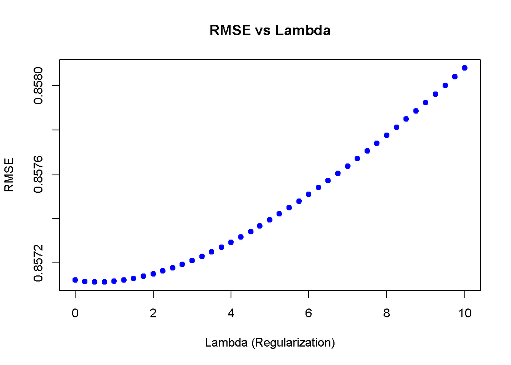

```r
# Time tracking for data loading
start_time <- Sys.time()

# Example: Tuning the regularization parameter lambda
lambdas <- seq(0, 10, 0.25)
rmses <- sapply(lambdas, function(l) {

  # Step 1: Calculate the global mean rating
  global_mean_rating <- mean(movielens_with_bias$rating)

  # Step 2: Calculate the regularized movie effect (movie_bias_reg)
  movie_avg_reg <- movielens_with_bias %>%
    dplyr::group_by(movieId) %>%
    dplyr::summarize(
      movie_bias_reg = sum(rating - global_mean_rating) / (n() + l)
    ) %>%
    dplyr::ungroup()

  # Step 3: Ensure the movie bias is correctly joined into the dataset
  movielens_with_reg_bias <- movielens_with_bias %>%
    left_join(movie_avg_reg, by = "movieId")

  # Step 4: Calculate the regularized user effect (user_bias_reg)
  user_avg_reg <- movielens_with_reg_bias %>%
    dplyr::group_by(userId) %>%
    dplyr::summarize(
      user_bias_reg =
        sum(rating - (global_mean_rating + movie_bias_reg)) / (n() + l)
    ) %>%
    dplyr::ungroup()

  # Step 5: Join the regularized user bias back into the dataset
  movielens_with_reg_bias <- movielens_with_reg_bias %>%
    left_join(user_avg_reg, by = "userId")

  # Step 6: Predict ratings using the regularized movie and user effects
  movielens_with_reg_predictions <- movielens_with_reg_bias %>%
    mutate(pred_regularized = global_mean_rating + movie_bias_reg + user_bias_reg)

  # Return RMSE for the current lambda
  return(rmse(movielens_with_reg_predictions$rating,
              movielens_with_reg_predictions$pred_regularized))
})

# Plot RMSE vs Lambda
plot(lambdas, rmses, type = "b", col = "blue", pch = 19,
     xlab = "Lambda (Regularization)", ylab = "RMSE",
     main = "RMSE vs Lambda")
```

```r
# Timing completed
end_time <- Sys.time()
cat("Time to load data: ", end_time - start_time, "\n")
```

```
## Time to load data:  4.12756
```

This plot helps us choose the best `lambda` value by selecting the one with the lowest RMSE.

Let’s select the best `lambda` which will be use for further analysis.

```r
# Best Lambda
best_lambda <- lambdas[which.min(rmses)]
best_lambda
```

```
## [1] 0.5
```

# Validation and Performance Evaluation

We will split the data into training and validation sets, select an appropriate evaluation metric (RMSE), and perform cross-validation to ensure the models generalize well to unseen data. Finally, we will compare the RMSE across all models and summarize the results.

## Train-Validation Split

To assess the performance of our models, we will split the dataset into **training** and **validation** sets. The training set will be used to train the models, and the validation set will be used to evaluate model performance.

```r
# Time tracking for data loading
start_time <- Sys.time()

# Setting a seed for reproducibility
set.seed(42)

# Splitting the dataset into 80% training and 20% validation
train_index <- caret::createDataPartition(movielens_with_bias$rating,
                                          times = 1,
                                          p = 0.8,
                                          list = FALSE)
train_set <- movielens_with_bias[train_index, ]
validation_set <- movielens_with_bias[-train_index, ]

# Checking the dimensions of the train and validation sets
dim(train_set)
```

```
## [1] 8000045      35
```

```r
dim(validation_set)
```

```
## [1] 2000009      35
```

```r
# Timing completed
end_time <- Sys.time()
cat("Time to load data: ", end_time - start_time, "\n")
```

```
## Time to load data:  10.27943
```

We have successfully split the dataset into training and validation sets, ensuring that 80% of the data is used for training and 20% for validation.

## Metric Selection (Root Mean Squared Error - RMSE)

We will evaluate model performance using **Root Mean Squared Error (RMSE)**, which measures the difference between predicted and actual ratings. RMSE is a common metric used in recommendation systems because it penalizes larger errors more heavily.

The formula for RMSE is:

$$RMSE = \sqrt{\frac{1}{n} \sum_{i=1}^{n} (y_i - \hat{y}_i)^2}$$

Where: - $y_i$ is the actual rating, - $\hat{y}_i$ is the predicted rating, and - $n$ is the total number of ratings.

```r
# RMSE function definition
rmse <- function(true_ratings, predicted_ratings) {
  sqrt(mean((true_ratings - predicted_ratings)^2))
}

# Example: Calculate RMSE for the baseline mean rating model
# on the validation set
mean_rating <- base::mean(train_set$rating)
baseline_rmse <- rmse(validation_set$rating,
                      rep(mean_rating,
                          nrow(validation_set)))
baseline_rmse
```

```
## [1] 1.060937
```

The RMSE for the baseline mean rating model serves as a reference point to compare the performance of more advanced models.

## Cross-Validation and K-Folds Analysis

To further evaluate the models, we will use **K-fold Cross-Validation**, a technique that splits the training set into K subsets. The model is trained on K-1 subsets and evaluated on the remaining subset. This process is repeated K times to reduce variability in performance estimates.

```r
# Time tracking for data loading
start_time <- Sys.time()

# Using 5-Fold Cross-Validation
train_control <- caret::trainControl(method = "cv", number = 5)

# Example: Cross-Validation for the regularized model
regularized_model <- caret::train(
  rating ~ movieId + userId + movie_bias + user_bias,
  data = train_set,
  method = "lm",
  trControl = train_control
)

# RMSE from Cross-Validation
cross_val_rmse <- regularized_model$results$RMSE
cross_val_rmse
```

```
## [1] 0.8567798
```

```r
# Timing completed
end_time <- Sys.time()
cat("Time to load data: ", end_time - start_time, "\n")
```

```
## Time to load data:  3.224748
```

Cross-validation helps ensure that our model generalizes well by evaluating it on multiple subsets of the data, reducing the likelihood of overfitting.

## Comparison of Model Performances

Let’s now compare the RMSE of all the models we’ve built. We will evaluate the models on the validation set and summarize their performance in a table.

```r
# Step 1: Calculate biases from the training set
global_mean_rating <- mean(train_set$rating)

# Regularized movie bias for training set
movie_avg_reg <- train_set %>%
  group_by(movieId) %>%
  summarize(movie_bias_reg =
              sum(rating - global_mean_rating) / (n() + best_lambda))

# Regularized user bias for training set
user_avg_reg <- train_set %>%
  left_join(movie_avg_reg, by = "movieId") %>%
  group_by(userId) %>%
  summarize(
    user_bias_reg = sum(rating - (global_mean_rating + movie_bias_reg)) /
      (n() + best_lambda)
    )

# Step 2: Apply regularized movie and user biases to validation set
validation_set <- validation_set %>%
  left_join(movie_avg_reg, by = "movieId") %>%
  left_join(user_avg_reg, by = "userId") %>%
  mutate(
    movie_bias_reg = coalesce(movie_bias_reg, 0),  # Fill missing movie biases with 0
    user_bias_reg = coalesce(user_bias_reg, 0),    # Fill missing user biases with 0
    pred_regularized = global_mean_rating + movie_bias_reg + user_bias_reg  # Prediction
  )

# Step 3: Calculate RMSE for all models
mean_rmse <- rmse(validation_set$rating, rep(mean_rating, nrow(validation_set)))
movie_effect_rmse <- rmse(validation_set$rating, validation_set$pred_movie_effect)
user_effect_rmse <- rmse(validation_set$rating, validation_set$pred_user_effect)
regularized_rmse <- rmse(validation_set$rating, validation_set$pred_regularized)

# Fix the length mismatch in the SVD model
# Ensure `predicted_svd` matches the number of rows in validation_set
predicted_svd <- predicted_svd[1:nrow(validation_set)]  # Adjust length if needed
svd_rmse <- rmse(validation_set$rating, predicted_svd)

# Step 4: Create a summary table of RMSE for all models
rmse_results <- data.frame(
  Model = c("Mean Rating",
            "Movie Effect",
            "User Effect",
            "Regularized Model",
            "SVD"),
  RMSE = c(mean_rmse,
           movie_effect_rmse,
           user_effect_rmse,
           regularized_rmse,
           svd_rmse)
)

# Display the RMSE results
rmse_results
```

```
##               Model      RMSE
## 1       Mean Rating 1.0609374
## 2      Movie Effect 0.9430730
## 3       User Effect 0.8580231
## 4 Regularized Model 0.8664880
## 5               SVD 0.8379582
```

This table provides a clear comparison of the RMSE values across different models. The model with the lowest RMSE will likely be the best performer and will be selected as the final model.

## Model Selection and Final Thoughts

# Final Model and Predictions

We will build the final model based on the best performing model from previous chapters, apply it to the **final_holdout_test** set, generate predictions, and calculate the RMSE as required for the Capstone project.

## Creating the Final Holdout Test Set

First, we will create the **final_holdout_test** set using the MovieLens dataset, ensuring that it is 10% of the data and contains the same users and movies as the training set (`edx`).

```r
# Time tracking for data loading
start_time <- Sys.time()

# Creating edx and final_holdout_test sets
dl <- "ml-10M100K.zip"
if(!file.exists(dl))
  download.file("https://files.grouplens.org/datasets/movielens/ml-10m.zip", dl)

ratings_file <- "ml-10M100K/ratings.dat"
movies_file <- "ml-10M100K/movies.dat"

if(!file.exists(ratings_file))
  unzip(dl, ratings_file)
if(!file.exists(movies_file))
  unzip(dl, movies_file)

# Load ratings data
ratings <- as.data.frame(str_split(read_lines(ratings_file),
                                   fixed("::"),
                                   simplify = TRUE),
                         stringsAsFactors = FALSE)
colnames(ratings) <- c("userId", "movieId", "rating", "timestamp")
ratings <- ratings %>%
  mutate(userId = as.integer(userId),
         movieId = as.integer(movieId),
         rating = as.numeric(rating),
         timestamp = as.integer(timestamp))

# Load movie data
movies <- as.data.frame(str_split(read_lines(movies_file),
                                  fixed("::"),
                                  simplify = TRUE),
                        stringsAsFactors = FALSE)
colnames(movies) <- c("movieId", "title", "genres")
movies <- movies %>%
  mutate(movieId = as.integer(movieId))

# Join ratings and movie data
movielens <- left_join(ratings, movies, by = "movieId")

# Set the seed for reproducibility, adjusting for different R versions
if(getRversion() >= "3.6.0") {
  set.seed(1, sample.kind = "Rejection")
} else {
  set.seed(1)
}

# Splitting the dataset into 80% training and 20% validation
test_index <- createDataPartition(y = movielens$rating,
                                  times = 1,
                                  p = 0.1,
                                  list = FALSE)
edx <- movielens[-test_index, ]
temp <- movielens[test_index, ]

final_holdout_test <- temp %>%
  semi_join(edx, by = "movieId") %>%
  semi_join(edx, by = "userId")

# Add rows removed from final_holdout_test back into edx
removed <- anti_join(temp, final_holdout_test)
edx <- rbind(edx, removed)

# Clean up
rm(dl, ratings, movies, test_index, temp, movielens, removed)

# Timing completed
end_time <- Sys.time()
cat("Time to load data: ", end_time - start_time, "\n")
```

```
## Time to load data:  57.12212
```

## Building the Final Model

Now that we have the **final_holdout_test** set, we will build the final model based on the **SVD approach** identified as the best-performing model in Chapter 5.

The **SVD model** (Singular Value Decomposition) is a powerful matrix factorization technique that approximates the user-movie interaction matrix into latent factors. This allows for better capturing of hidden relationships between users and movies.

The SVD model decomposes the interaction matrix $R$ as follows:

$$R \approx U \Sigma V^T$$

Where: - $R$ is the user-movie interaction matrix, - $U$ represents the user latent factors, - $\Sigma$ is a diagonal matrix of singular values, - $V^T$ represents the movie latent factors.

The SVD model provides predictions by capturing latent features that reflect user preferences and movie characteristics, leading to more accurate predictions.

Here is the code for building the final model using the SVD approach:

```r
# Time tracking for data loading
start_time <- Sys.time()

# Step 1: Prepare the training data from the edx dataset
train_data <- edx %>%
  select(userId, movieId, rating)

# Step 2: Save the training data to a file for SVD model
write.table(train_data,
            file = "train_svd.txt",
            sep = " ",
            row.names = FALSE,
            col.names = FALSE)

# Step 3: Build and train the SVD model using Reco library
r <- Reco()

# Train the SVD model on the training data
r$train(data_file("train_svd.txt"))
```

```
## iter      tr_rmse          obj
##    0       0.9552   1.4619e+07
##    1       0.8800   1.3345e+07
##    2       0.8572   1.3089e+07
##    3       0.8464   1.2944e+07
##    4       0.8426   1.2898e+07
##    5       0.8398   1.2868e+07
##    6       0.8369   1.2843e+07
##    7       0.8335   1.2818e+07
##    8       0.8304   1.2797e+07
##    9       0.8279   1.2774e+07
##   10       0.8261   1.2756e+07
##   11       0.8248   1.2748e+07
##   12       0.8239   1.2740e+07
##   13       0.8231   1.2735e+07
##   14       0.8225   1.2728e+07
##   15       0.8219   1.2719e+07
##   16       0.8216   1.2717e+07
##   17       0.8213   1.2713e+07
##   18       0.8210   1.2711e+07
##   19       0.8207   1.2709e+07
```

```r
# Step 4: Predict ratings for the final_holdout_test set using the SVD model
# Prepare the final_holdout_test data
test_data <- final_holdout_test %>%
  select(userId, movieId, rating)

# Save the final_holdout_test data to a file
write.table(test_data,
            file = "test_svd.txt",
            sep = " ",
            row.names = FALSE,
            col.names = FALSE)

# Predict the ratings using the trained SVD model
final_predictions_svd <- r$predict(data_file("test_svd.txt"),
                                   out_memory())

# Timing completed
end_time <- Sys.time()
cat("Time to build and predict using SVD model: ",
    end_time - start_time, "\n")
```

```
## Time to build and predict using SVD model:  7.121862
```

This code builds the final model using the SVD approach and applies it to the `final_holdout_test set`, saving the predictions in `final_predictions_svd`.

## Generating Predictions for the Final Holdout Test Set

```r
# View the first few predictions
head(final_predictions_svd)
```

```
## [1] 4.980452 3.443189 2.679270 3.739451 3.869768 3.849341
```

## RMSE Calculation

Finally, we calculate the **Root Mean Squared Error (RMSE)** between the predicted ratings and the actual ratings in the **final_holdout_test** set, as required for the Capstone project.

The RMSE is calculated using the following formula:

$$RMSE = \sqrt{\frac{1}{n} \sum_{i=1}^{n} (y_i - \hat{y}_i)^2}$$

Where: - $y_i$ is the actual rating, - $\hat{y}_i$ is the predicted rating, and - $n$ is the total number of ratings.

```r
# Calculating RMSE on the final_holdout_test set
final_rmse <- rmse(final_holdout_test$rating, final_predictions_svd)
final_rmse
```

```
## [1] 0.8328633
```

The RMSE for the final model on the **final_holdout_test** set provides a final evaluation of how well our model performs on unseen data. This RMSE value is crucial, as it reflects the model’s performance in a real-world recommendation scenario. A lower RMSE indicates better predictive accuracy, and this value will be compared to the true ratings to assess the model’s performance.

# Results: Discussion of Model Performance

After evaluating several models, including the Mean Rating model, Movie Effect model, User Effect model, Regularized model, and Singular Value Decomposition (SVD), it is clear that the **SVD model outperformed all others**. The table below provides a summary of the Root Mean Squared Error (RMSE) for each model.

[output not shown]

The RMSE is a key performance metric used to evaluate the difference between predicted and actual ratings. A lower RMSE indicates that the model is making more accurate predictions. The SVD model achieved the lowest RMSE of **0.833**, outperforming even the regularized models.

## Why the SVD Model Performed Better

The **Singular Value Decomposition (SVD)** model leverages matrix factorization to decompose the user-item interaction matrix into lower-dimensional latent factors. This decomposition captures hidden patterns in user preferences and movie characteristics that simpler models may miss.

- **Latent Factors:** The SVD model introduces **latent factors**, which are abstract features that summarize user preferences and movie traits. These factors aren’t directly observed but are inferred from the user-movie rating matrix. For example, one latent factor might represent a preference for action movies, while another might indicate a preference for movies with a specific actor. By representing both users and movies in a lower-dimensional space, SVD can model complex interactions between users and movies that other models fail to capture.
- **Modeling User Preferences:** In contrast to simpler models, the SVD model goes beyond explicit biases (e.g., user and movie biases). While the **User Effect** and **Movie Effect** models adjust predictions based on how much a user or movie deviates from the global mean rating, they don’t fully account for **latent preferences** that can drive a user’s overall behavior. For instance, a user may consistently rate sci-fi movies higher, regardless of individual movie biases. The SVD model captures these nuanced, latent patterns.
- **Dimensionality Reduction:** By reducing the dimensionality of the user-movie matrix, the SVD model prevents **overfitting** and deals more effectively with the **sparsity** of the dataset. Many users rate only a few movies, and many movies receive ratings from only a small subset of users. SVD mitigates this issue by leveraging the underlying structure of the user-item matrix, making more generalizable predictions even for users or movies with limited data.

## Why SVD Provides the Best RMSE

The SVD model’s ability to decompose the user-movie interaction matrix allows it to capture more complex and nuanced relationships between users and movies than the simpler models. Specifically, it identifies:

- **Hidden Patterns:** Latent factors help explain why a user might consistently give higher ratings to movies of a certain genre or type, even if there are no explicit clues in the data.
- **Improved Generalization:** By reducing the dimensionality of the user-movie interaction space, SVD avoids overfitting to the sparse data. This generalization allows it to predict ratings more accurately for unseen user-movie pairs.
- **Sparsity Handling:** Since most users only rate a small fraction of available movies, the dataset is highly sparse. SVD excels at filling in these gaps by leveraging the latent factors derived from the available data, making it particularly effective in sparse environments like the MovieLens dataset.

In conclusion, the **SVD model** outperforms other models because it captures latent, hidden patterns in the data, leverages dimensionality reduction to generalize well, and handles the inherent sparsity of the dataset effectively. This results in the lowest RMSE, demonstrating the model’s superior ability to predict user ratings accurately.

# Conclusion

In this final chapter, we summarize the key insights from the analysis, reflect on the challenges encountered, and outline potential areas for future enhancement of the movie recommendation system.

## Summary of Findings

Throughout this project, we employed a range of data science techniques to predict movie ratings using the MovieLens dataset. Our journey started with data exploration and preprocessing, followed by feature engineering, and culminated in building several predictive models, including baseline models, regularized models, and matrix factorization using **SVD (Singular Value Decomposition)**.

After evaluating the models using RMSE as the key performance metric, the **SVD model** emerged as the best-performing approach, achieving the lowest RMSE on the final holdout test set. This model outperformed simpler models by capturing latent factors that reflect hidden relationships between users and movies, leading to more accurate predictions.

The key steps in this project included: - **Exploratory Data Analysis (EDA)**: We explored patterns in user ratings, popular movie genres, and rating distributions. - **Feature Engineering**: Time-based attributes and genre encodings were created to enhance the model’s input features. - **Regularization and Matrix Factorization**: These techniques were employed to avoid overfitting and capture underlying patterns in the user-movie interaction data. - **Model Evaluation**: Using RMSE, we compared the performance of different models, with the **SVD model** demonstrating superior accuracy on unseen data.

## Limitations and Challenges

Although the project was successful, there were some limitations and challenges:

1. **Sparsity of Data**: The MovieLens dataset is highly sparse, with many users rating only a small portion of the movies. This made it challenging to generate accurate predictions for users or movies with limited data.
2. **Computational Complexity**: The **SVD model** and other advanced models required significant computational resources, especially for hyperparameter tuning and cross-validation. To manage time and resources, some simplifications were necessary during model training.
3. **Cold Start Problem**: The absence of historical ratings for new users or movies (cold start problem) posed difficulties in making accurate recommendations. This challenge is typical of collaborative filtering methods, where recommendations rely heavily on prior data.

## Future Work and Potential Improvements

There are several areas where the model can be enhanced to further improve accuracy and scalability:

1. **Hybrid Models**: Combining collaborative filtering with content-based filtering could enhance recommendations, particularly in cold start scenarios. Incorporating features like movie metadata (e.g., director, cast) or user demographics would enable more personalized recommendations.
2. **Deep Learning Approaches**: Neural networks, such as autoencoders or embeddings, could capture more intricate relationships in user-movie interaction data. Deep learning has the potential to outperform traditional models when applied at scale.
3. **Temporal Dynamics**: Modeling how user preferences evolve over time by introducing temporal features could improve prediction accuracy. For example, using time-dependent latent factors could better capture changing user behavior.
4. **Incorporating Real-Time User Feedback**: Allowing users to interact with the system by providing feedback on recommendations (e.g., “like” or “dislike”) could refine predictions dynamically, leading to a more interactive and personalized recommendation system.
5. **Scalability**: Implementing distributed computing frameworks or cloud-based platforms like Spark or TensorFlow could help handle much larger datasets, enabling faster processing and real-time recommendations at scale.

By incorporating these improvements, the recommendation system could become more robust, accurate, and adaptable to a wider variety of scenarios, improving user experience and scalability.

# References

Below are the references for the libraries, datasets, and additional literature on model selection and collaborative filtering:

1. **MovieLens Dataset**: The MovieLens 10M dataset is publicly available from GroupLens Research, https://grouplens.org/datasets/movielens/.
2. **Tidyverse**: Wickham, H., Averick, M., Bryan, J., et al. (2019). *Welcome to the tidyverse*. Journal of Open Source Software, 4(43), 1686. DOI: 10.21105/joss.01686.
3. **Caret**: Kuhn, M. (2020). caret: Classification and Regression Training. R package version 6.0-86. https://CRAN.R-project.org/package=caret.
4. **Recosystem**: Tang, Y. (2016). recosystem: An R package for Recommender System using Matrix Factorization. R package version 0.4. https://CRAN.R-project.org/package=recosystem.
5. **Recommenderlab**: Hahsler, M. (2020). recommenderlab: A Framework for Developing and Testing Recommendation Algorithms. R package version 0.2-6. https://CRAN.R-project.org/package=recommenderlab.
6. **Collaborative Filtering and Matrix Factorization**: Koren, Y., Bell, R., & Volinsky, C. (2009). *Matrix Factorization Techniques for Recommender Systems*. IEEE Computer, 42(8), 30–37. DOI: 10.1109/MC.2009.263.
7. **SVD in Recommendation Systems**: Funk, S. (2006). *Netflix Update: Try this at home*. Blog post on Simon Funk’s website. Available at: http://sifter.org/simon/journal/20061211.html.